# CEP-0351 Sample Information

Adam Fletcher

### Study Overview

Objective in the trial in to identify DNA methylation markers from patients at baseline and post-treatment to determine at methylation pattern changes which could lead to chemotherapy resistance.

Each timepoint will involve the collection of two blood samples 1x **Cell Save** and 1x **Streck**.

The **Cell Save** sample will run on the *Cell Search* platform to enrich for EpCAM+, DAPI+ and CD45- Cells, any samples with count >5 CTCs will be run on the DEP Array for single cell isolatoion

The **Streck** sample will be run through the *Parsortix* platform which is an epitope independent, size selection methodology. All samples will have 50% of the Parsortix output banked in Glycerol, with the other 50% having the Total Nuceleic Acid (TNA) content extracted. Additionally, *cfDNA* will be extracted from the Parsortix sample.

### Sample Shipment and Reciept

The project specifies that samples must be recieved with 96 Hours of shipment from Sloan Kettering.

The graph below shows the time taken to arrive in Manchester based upon date of shipment for each sample currently enrolled on CEP-0351.

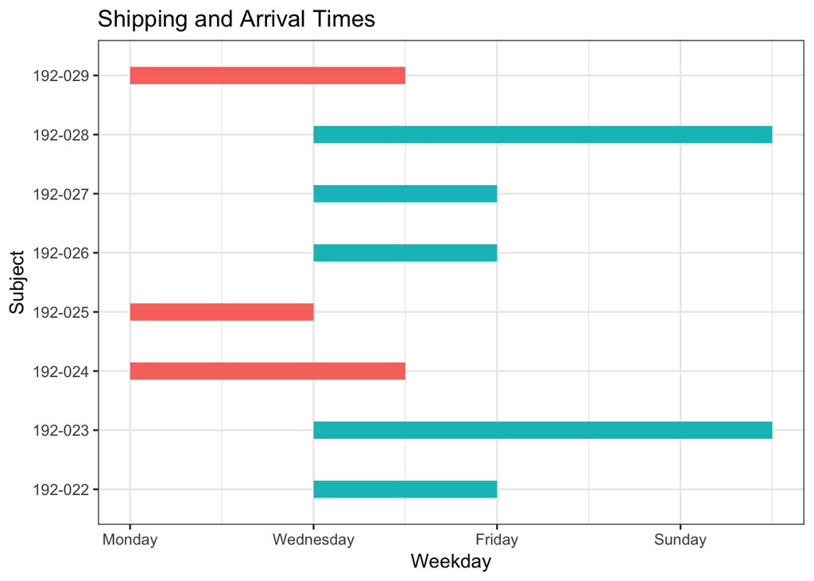

[figure not shown]

[figure not shown]